# week07 - answer

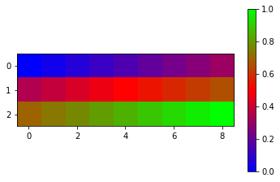

```python
plt.figure()
cmaps = ['Accent', 'Accent_r', 'Blues', 'Blues_r', 'BrBG', 'BrBG_r', 'BuGn', 'BuGn_r', 'BuPu', 'BuPu_r', 'CMRmap', 'CMRmap_r', 'Dark2', 'Dark2_r', 'GnBu', 'GnBu_r', 'Greens', 'Greens_r', 'Greys', 'Greys_r', 'OrRd', 'OrRd_r', 'Oranges', 'Oranges_r', 'PRGn', 'PRGn_r', 'Paired', 'Paired_r', 'Pastel1', 'Pastel1_r', 'Pastel2', 'Pastel2_r', 'PiYG', 'PiYG_r', 'PuBu', 'PuBuGn', 'PuBuGn_r', 'PuBu_r', 'PuOr', 'PuOr_r', 'PuRd', 'PuRd_r', 'Purples', 'Purples_r', 'RdBu', 'RdBu_r', 'RdGy', 'RdGy_r', 'RdPu', 'RdPu_r', 'RdYlBu', 'RdYlBu_r', 'RdYlGn', 'RdYlGn_r', 'Reds', 'Reds_r', 'Set1', 'Set1_r', 'Set2', 'Set2_r', 'Set3', 'Set3_r', 'Spectral', 'Spectral_r', 'Wistia', 'Wistia_r', 'YlGn', 'YlGnBu', 'YlGnBu_r', 'YlGn_r', 'YlOrBr', 'YlOrBr_r', 'YlOrRd', 'YlOrRd_r', 'afmhot', 'afmhot_r', 'autumn', 'autumn_r', 'binary', 'binary_r', 'bone', 'bone_r', 'brg', 'brg_r', 'bwr', 'bwr_r', 'cividis', 'cividis_r', 'cool', 'cool_r', 'coolwarm', 'coolwarm_r', 'copper', 'copper_r', 'cubehelix', 'cubehelix_r', 'flag', 'flag_r', 'gist_earth', 'gist_earth_r', 'gist_gray', 'gist_gray_r', 'gist_heat', 'gist_heat_r', 'gist_ncar', 'gist_ncar_r', 'gist_rainbow', 'gist_rainbow_r', 'gist_stern', 'gist_stern_r', 'gist_yarg', 'gist_yarg_r', 'gnuplot', 'gnuplot2', 'gnuplot2_r', 'gnuplot_r', 'gray', 'gray_r', 'hot', 'hot_r', 'hsv', 'hsv_r', 'inferno', 'inferno_r', 'jet', 'jet_r', 'magma', 'magma_r', 'nipy_spectral', 'nipy_spectral_r', 'ocean', 'ocean_r', 'pink', 'pink_r', 'plasma', 'plasma_r', 'prism', 'prism_r', 'rainbow', 'rainbow_r', 'seismic', 'seismic_r', 'spring', 'spring_r', 'summer', 'summer_r', 'tab10', 'tab10_r', 'tab20', 'tab20_r', 'tab20b', 'tab20b_r', 'tab20c', 'tab20c_r', 'terrain', 'terrain_r', 'turbo', 'turbo_r', 'twilight', 'twilight_r', 'twilight_shifted', 'twilight_shifted_r', 'viridis', 'viridis_r', 'winter', 'winter_r']
plt.imshow(X,interpolation='none', origin='upper', cmap='brg')
# http://matplotlib.org/examples/images_contours_and_fields/interpolation_methods.html
plt.colorbar(shrink=.92) #shrink:用于调整比例，用于调整色块
pass
```

3d图

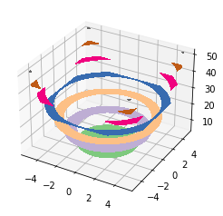

```python
from mpl_toolkits.mplot3d import Axes3D

x_arr = np.linspace(-5, 5, 100).reshape(1,100)
y_arr = np.linspace(-5, 5, 100).reshape(100,1)
fig = plt.figure()
ax = plt.axes(projection='3d')
# ax.contour(X, Y, Z, *args, extend3d=False, stride=5, zdir='z', offset=None, data=None, **kwargs)
# ax.contourf(X, Y, Z, *args, zdir='z', offset=None, data=None, **kwargs)
cmaps = ['Accent', 'Accent_r', 'Blues', 'Blues_r', 'BrBG', 'BrBG_r', 'BuGn', 'BuGn_r', 'BuPu', 'BuPu_r', 'CMRmap', 'CMRmap_r', 'Dark2', 'Dark2_r', 'GnBu', 'GnBu_r', 'Greens', 'Greens_r', 'Greys', 'Greys_r', 'OrRd', 'OrRd_r', 'Oranges', 'Oranges_r', 'PRGn', 'PRGn_r', 'Paired', 'Paired_r', 'Pastel1', 'Pastel1_r', 'Pastel2', 'Pastel2_r', 'PiYG', 'PiYG_r', 'PuBu', 'PuBuGn', 'PuBuGn_r', 'PuBu_r', 'PuOr', 'PuOr_r', 'PuRd', 'PuRd_r', 'Purples', 'Purples_r', 'RdBu', 'RdBu_r', 'RdGy', 'RdGy_r', 'RdPu', 'RdPu_r', 'RdYlBu', 'RdYlBu_r', 'RdYlGn', 'RdYlGn_r', 'Reds', 'Reds_r', 'Set1', 'Set1_r', 'Set2', 'Set2_r', 'Set3', 'Set3_r', 'Spectral', 'Spectral_r', 'Wistia', 'Wistia_r', 'YlGn', 'YlGnBu', 'YlGnBu_r', 'YlGn_r', 'YlOrBr', 'YlOrBr_r', 'YlOrRd', 'YlOrRd_r', 'afmhot', 'afmhot_r', 'autumn', 'autumn_r', 'binary', 'binary_r', 'bone', 'bone_r', 'brg', 'brg_r', 'bwr', 'bwr_r', 'cividis', 'cividis_r', 'cool', 'cool_r', 'coolwarm', 'coolwarm_r', 'copper', 'copper_r', 'cubehelix', 'cubehelix_r', 'flag', 'flag_r', 'gist_earth', 'gist_earth_r', 'gist_gray', 'gist_gray_r', 'gist_heat', 'gist_heat_r', 'gist_ncar', 'gist_ncar_r', 'gist_rainbow', 'gist_rainbow_r', 'gist_stern', 'gist_stern_r', 'gist_yarg', 'gist_yarg_r', 'gnuplot', 'gnuplot2', 'gnuplot2_r', 'gnuplot_r', 'gray', 'gray_r', 'hot', 'hot_r', 'hsv', 'hsv_r', 'inferno', 'inferno_r', 'jet', 'jet_r', 'magma', 'magma_r', 'nipy_spectral', 'nipy_spectral_r', 'ocean', 'ocean_r', 'pink', 'pink_r', 'plasma', 'plasma_r', 'prism', 'prism_r', 'rainbow', 'rainbow_r', 'seismic', 'seismic_r', 'spring', 'spring_r', 'summer', 'summer_r', 'tab10', 'tab10_r', 'tab20', 'tab20_r', 'tab20b', 'tab20b_r', 'tab20c', 'tab20c_r', 'terrain', 'terrain_r', 'turbo', 'turbo_r', 'twilight', 'twilight_r', 'twilight_shifted', 'twilight_shifted_r', 'viridis', 'viridis_r', 'winter', 'winter_r']
# plt.contour(x_arr.flatten(), y_arr.flatten(), (x_arr)**2+(y_arr)**2, zdir='z', offset=None, cmap=cmaps[0])
plt.contourf(x_arr.flatten(), y_arr.flatten(), (x_arr)**2+(y_arr)**2, zdir='z', offset=None, cmap=cmaps[0])

# help(ax.plot_surface)
# plot_surface(X, Y, Z, *args, norm=None, vmin=None, vmax=None, lightsource=None, **kwargs)
# ax.plot_surface(x_arr, y_arr, np.sin((x_arr**2+y_arr**2)**0.5), rstride=5,cstride=5,cmap='rainbow')
```

subplot

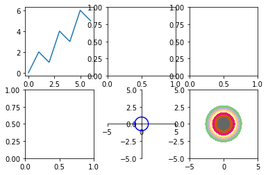

```python
plt.figure()
# help(plt.subplot())
plt.subplot(2,3,1)
plt.plot([0,2,1,4,3,6,5])

plt.subplot(2,3,2)

plt.subplot(2,3,3)
plt.subplot(2,3,4)
x_arr = np.linspace(-5, 5, 100).reshape(1,100)
y_arr = np.linspace(-5, 5, 100).reshape(100,1)
plt.subplot(2,3,5)
plt.contour(x_arr.flatten(), y_arr.flatten(), radius**2-(x_arr-a)**2-(y_arr-b)**2, [0], colors='b')
ax = plt.gca()
ax.spines['right'].set_color('none')
ax.spines['top'].set_color('none')
ax.xaxis.set_ticks_position('bottom')
ax.yaxis.set_ticks_position('left')
ax.spines['bottom'].set_position(('data', 0))
ax.spines['left'].set_position(('data', 0))

plt.subplot(2,3,6)
plt.contourf(x_arr.flatten(), y_arr.flatten(), (x_arr)**2+(y_arr)**2, np.arange(8), cmap='Accent_r')
```

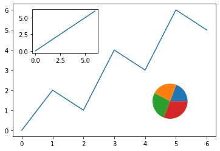

```python
fig = plt.figure()

plt.plot([0,2,1,4,3,6,5])

left, bottom, width, height = 0.6, 0.2, 0.25, 0.25
ax1 = fig.add_axes([left, bottom, width, height])
ax1.pie(np.arange(5,9))

left, bottom, width, height = 0.2, 0.6, 0.25, 0.25
ax2 = fig.add_axes([left, bottom, width, height])
ax2.plot([0,1,2,3,4,5,6])
```

组合展示  
来自[matplotlib:各种基础图形绘制 - Mr.H520的文章 - 知乎](https://zhuanlan.zhihu.com/p/363844187)

[output not shown]

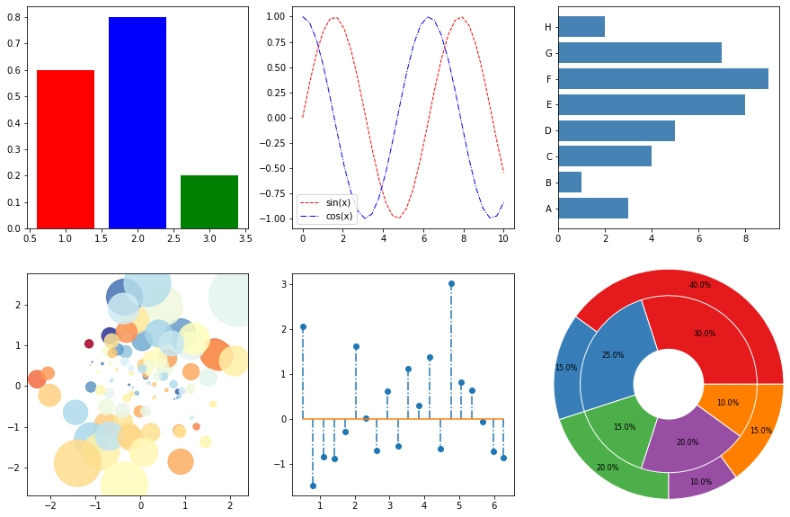

```python
#生成两行三列15×10的6个子图；
fig, axes = plt.subplots(2, 3, figsize=(15, 10))
ax1, ax2, ax3, ax4, ax5, ax6 = axes.flatten() #将当前展开
#第一个子图
#要求：绘制三种不同的颜色，绘制条形图
ax1.bar([1, 2, 3],[0.6, 0.8, 0.2],color=list('rbg'))

#第二个子图
'''
绘制sin(x)和cos(x)的图像；
样式：
横轴设为'x'，纵轴设为'f(x)'；
添加图例：sin(x)和cos(x);
颜色不同，线型不同；
图形：绘制线图；
'''
x = np.linspace(0, 10, 30)
ax2.plot(x,np.sin(x),color='r',linewidth=1.0,linestyle='--',label='sin(x)')
ax2.plot(x,np.cos(x),color='b',linewidth=1.0,linestyle='-.',label='cos(x)')
ax2.set_xlabel='x'
ax2.set_ylabel='f(x)'
ax2.legend()

#第三个子图
'''
数据：x=[1,2,3,4,5,6,7,8]; y= [3,1,4,5,8,9,7,2]
样式：
纵轴标签设为：['A','B','C','D','E','F','G','H']
图形：绘制水平条形图；
'''
ax3.barh([1,2,3,4,5,6,7,8],[3,1,4,5,8,9,7,2],color='steelblue',tick_label=['A','B','C','D','E','F','G','H'])
ax3.set_yticks([1,2,3,4,5,6,7,8],['A','B','C','D','E','F','G','H'])



#第四个子图
'''
生成两组服从正态分布的100个随机数,设为x,y；
样式：
颜色主题：采用mpl.cm.RdYlBu；
标注：采用'o'；
图形：绘制气泡图；
'''
np.random.seed(1)
x1 = np.random.normal(0,1,100)
y1 = np.random.normal(0,1,100)
colors = np.random.randn(100)
ax4.scatter(x1,y1,
            c = colors,
            s = np.power(10*x1 + 20*y1,2),
            marker = 'o',
            cmap = 'RdYlBu',
            alpha = 0.85)

#第五个子图
'''
x = np.linspace(0.5,2*np.pi,20)
y = np.random.randn(20)
样式：
棉棒样式：'-.';
棉棒末端的样式:'o';
指定基线的样式:'-';
图形：绘制棉棒图；
'''
x2 = np.linspace(0.5,2*np.pi,20)
y2 = np.random.randn(20)
ax5.stem(x2,y2,linefmt='-.',markerfmt='o',basefmt='-')#棉棒图

#第六个子图
'''
数据：
elements = ["Flour","Sugar","Cream","Strawberry","Nuts"]
weight1 = [40,15,20,10,15]
weight2 = [30,25,15,20,10]
样式：
颜色设为：["#e41a1c","#377eb8","#4daf4a","#984ea3","#ff7f00"]
百分数保留一位小数；
其他参数自行发挥；
图形：绘制双层环形图；
'''
elements = ["Flour","Sugar","Cream","Strawberry","Nuts"]
weight1 = [40,15,20,10,15]
weight2 = [30,25,15,20,10]
colormapList = ["#e41a1c","#377eb8","#4daf4a","#984ea3","#ff7f00"]

ax6.pie(weight1,radius=1.3,autopct='%1.1f%%',pctdistance=0.9,colors=colormapList,wedgeprops=dict(edgecolor='w'),textprops={"fontsize":8})
ax6.pie(weight2,radius=1,autopct='%1.1f%%',pctdistance=0.7,colors=colormapList,wedgeprops=dict(edgecolor='w'),textprops={"fontsize":8})
ax6.pie([1],colors='w',radius=0.4)
```

动画

[figure not shown]

```python
# 源自 https://blog.csdn.net/miracleoa/article/details/115407901
from matplotlib import animation
# help(animation.FuncAnimation)
# animation.FuncAnimation(fig, func, frames=None, init_func=None, fargs=None, save_count=None, *, cache_frame_data=True, **kwargs)

# 生成子图，相当于fig = plt.figure(),ax = fig.add_subplot(),其中ax的函数参数表示把当前画布进行分割，
fig, ax = plt.subplots()
xdata, ydata = [], []
ln, = ax.plot([], [], animated=False)


def init():
    xdata, ydata = [], []
#     ax.set_xlim(0, 2 * np.pi)
    ax.set_ylim(-1, 1)
    # 返回曲线
    return ln,


def update(frame):
    ax.set_xlim(-2 * np.pi+frame, 2 * np.pi+frame)
    # 将每次传过来的n追加到xdata中
    if len(xdata) > 50 :
        del xdata[0]
        del ydata[0]
    xdata.append(frame)
    ydata.append(np.sin(frame))
    # 重新设置曲线的值
    ln.set_data(xdata, ydata)
    return ln,


# 函数FuncAnimation(fig,func,frames,init_func,interval,blit)是绘制动图的主要函数，其参数如下：
#     a.fig 绘制动图的画布名称
#     b.func自定义动画函数，即下边程序定义的函数update
#     c.frames动画长度，一次循环包含的帧数，在函数运行时，其值会传递给函数update(n)的形参“n”
#     d.init_func自定义开始帧，即传入刚定义的函数init,初始化函数
#     e.interval更新频率，以ms计
#     f.blit选择更新所有点，还是仅更新产生变化的点。应选择True，但mac用户请选择False，否则无法显示

plt.xticks([])
ani = animation.FuncAnimation(fig=fig, func=update, frames=np.linspace(-5 * np.pi, 5 * np.pi, 128),interval=50,
                    repeat=True, init_func=init, blit=True)
```

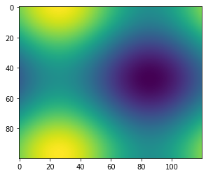

```python
# 源自: https://cloud.tencent.com/developer/article/1486959
fig = plt.figure()
def f(x, y):
    return np.sin(x) + np.cos(y)
x = np.linspace(0, 2 * np.pi, 120)
y = np.linspace(0, 2 * np.pi, 100).reshape(-1, 1)
im = plt.imshow(f(x, y), animated=True)

def updatefig(frame,x,y):
    x += np.pi / 15.
    y += np.pi / 20.
    im.set_array(f(x, y))
    return im,
ani = animation.FuncAnimation(fig, updatefig, frames = range(100), interval=50, blit=True,fargs=(x,y))
```

#### 练习0

椭圆曲线:  
$y^2 = x^3 + ax + b~~~((a,b) \in GF(p),~4a^3+27b^2 \neq 0)$  
自定义a, b,生成自己的椭圆曲线

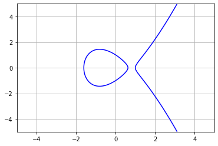

```python
a = -2
b = 1
assert 4 * a ** 3 - 27 * b ** 2 != 0, "4a^3+27b^2=0"

# https://stackoverflow.com/questions/19756043/python-matplotlib-elliptic-curves
x_arr = np.linspace(-5, 5, 100).reshape(1,100)
y_arr = np.linspace(-5, 5, 100).reshape(100,1)
fig = plt.figure()
plt.contour(x_arr.flatten(), y_arr.flatten(), y_arr ** 2 - x_arr ** 3 - a * x_arr - b, [0], colors='b')
plt.grid()
```

#### 练习1 BMI可视化

参考上上周作业练习2

> 使用numpy生成随机数组，以添加'身高(cm)'列，范围${\;}[140, 200]{\;}$; 和'体重(kg)'列，范围${\;}[30, 100]{\;}$  
> 添加BMI列，根据生成的身高体重列计算BMI$bmi = \frac{体重(kg)}{身高(m)^2}$

绘制一张散点图并分别画出男性和女性的BMI，其中点的大小由身高决定  
绘制一张箱型图分别统计男性和女性的BMI

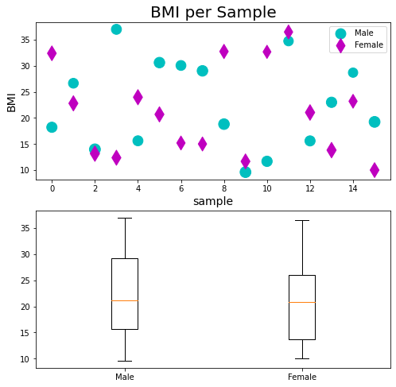

```python
data = [['Alex', 'M', 16], ['Alpha', 'M', 17], ['Allen', 'M', 18], ['Athena', 'F', 19],
        ['Chad', 'M', 17], ['Chole', 'F', 18], ['Dane', 'F', 19], ['Dale', 'F', 20],
        ['Frances', 'M', 18], ['Olivia', 'F', 19], ['Dave', 'M', 20], ['David', 'M', 21],
        ['John', 'M', 19], ['Ada', 'F', 20], ['Jane', 'F', 21], ['Ivy', 'F', 22],
        ['Julius', 'M', 20], ['Amy', 'F', 21], ['Irene', 'F', 22], ['Irma', 'F', 23],
        ['Jim', 'M', 21], ['Joseph', 'M', 22], ['Jenny', 'F', 23], ['Jennifer', 'F', 24],
        ['Micheal', 'M', 22], ['Crystal', 'F', 23], ['Claire', 'F', 24], ['Christine', 'F', 25],
        ['Kent', 'M', 23], ['Kenneth', 'M', 24], ['Justin', 'M', 25], ['Joyce', 'M', 26]]
df1 = pd.DataFrame(data, columns=['name', 'gender', 'age'])
def calBmi(df):
    df2 = df.copy()
    n = df2.shape[0]
    df2['height'] = np.random.randint(140,201,n)
    df2['weight'] = np.random.randint(30,101,n)
    df2['BMI'] = np.round(df2['weight']/df2['height']/df2['height']*10000,2)
    return df2
df1 = calBmi(df1)
df_m = df1[df1.gender == 'M'].reset_index()
df_f = df1[df1.gender == 'F'].reset_index()

plt.figure(figsize=(8,8))
plt.subplot(2,1,1)
plt.title('BMI per Sample', fontsize=20)
plt.xlabel('sample', fontsize=14)
plt.ylabel('BMI', fontsize=14)
plt.scatter(np.arange(16), df_m['BMI'], s=np.array(df_m['height']), marker='o',c='c')
plt.scatter(np.arange(16), df_f['BMI'], s=np.array(df_f['height']), marker='d',c='m')
plt.legend(labels=['Male', 'Female'], loc='best')

plt.subplot(2,1,2)
plt.boxplot([df_m['BMI'],df_f['BMI']], labels=['Male', 'Female'])
pass
```

#### 练习2

给出如下数据，其中性别M为男性，F为女性  
使用柱状图绘制各等级男性有几人，女性有几人，将两柱上下堆叠以显示共有几人,做好标签及图例  
将男女性的成绩(grade)绘制在同一张直方图上，并绘制正太分布的线性图

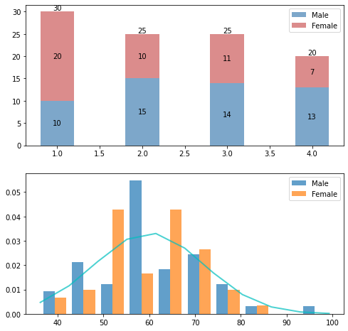

```python
data = np.array([np.random.randint(1, 5, 100),
       np.random.randint(0, 2, 100),
       np.random.normal(60, 12, 100)]).T
df = pd.DataFrame(data, columns=['level', 'gender', 'grade'])
df['gender'] = df['gender'].apply(lambda x : 'M' if x else 'F')
lv_m = []
lv_f = []
for i in range(1,5):
    # 要注意的是，&优先级比<、>、==高级，所以要记得加括号；
    # 还有就是and、or、not好像是被DataFrame/Series用于其他的运算了，因此不能用以代替&、|、~。
    lv_m.append(df[(df.gender=='M') & (df.level==i)].shape[0])
    lv_f.append(df[(df.gender=='F') & (df.level==i)].shape[0])

plt.figure(figsize=(8,8))
plt.subplot(2,1,1)
b1=plt.bar(np.arange(1,5), lv_m, label='Male', width=0.4, align='center', color='steelblue', alpha = 0.7)
b2=plt.bar(np.arange(1,5), lv_f, label='Female',bottom=lv_m, width=0.4, align='center', color='indianred', alpha = 0.7)
plt.legend(labels=['Male', 'Female'], loc='best')
plt.bar_label(b1, label_type='center')
plt.bar_label(b2, label_type='center')
plt.bar_label(b2)

plt.subplot(2,1,2)
count, bins, ignored = plt.hist([df[(df.gender=='M')]['grade'], df[(df.gender=='F')]['grade']], density=True, alpha=0.7)
plt.legend(labels=['Male', 'Female'], loc='best')
plt.plot(bins, 1/(12 * np.sqrt(2 * np.pi)) * np.exp( - (bins - 60)**2 / (2 * 12**2) ), linewidth=2, color='c', alpha=0.7)
pass
```

#### 练习3

在同一3D坐标轴中对如上椭圆曲线绘制两张图片  
一张绘制contourf且自定义任意colormap，将其压为平面并置于底部  
一张绘制plot_surface且colormap为'Accent'或'Accent_r'

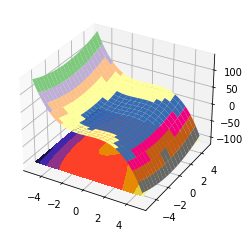

```python
x_arr = np.linspace(-5, 5, 100).reshape(1,100)
y_arr = np.linspace(-5, 5, 100).reshape(100,1)
fig = plt.figure()
ax = plt.axes(projection='3d')
cmaps = ['Accent', 'Accent_r', 'Blues', 'Blues_r', 'BrBG', 'BrBG_r', 'BuGn', 'BuGn_r', 'BuPu', 'BuPu_r', 'CMRmap', 'CMRmap_r', 'Dark2', 'Dark2_r', 'GnBu', 'GnBu_r', 'Greens', 'Greens_r', 'Greys', 'Greys_r', 'OrRd', 'OrRd_r', 'Oranges', 'Oranges_r', 'PRGn', 'PRGn_r', 'Paired', 'Paired_r', 'Pastel1', 'Pastel1_r', 'Pastel2', 'Pastel2_r', 'PiYG', 'PiYG_r', 'PuBu', 'PuBuGn', 'PuBuGn_r', 'PuBu_r', 'PuOr', 'PuOr_r', 'PuRd', 'PuRd_r', 'Purples', 'Purples_r', 'RdBu', 'RdBu_r', 'RdGy', 'RdGy_r', 'RdPu', 'RdPu_r', 'RdYlBu', 'RdYlBu_r', 'RdYlGn', 'RdYlGn_r', 'Reds', 'Reds_r', 'Set1', 'Set1_r', 'Set2', 'Set2_r', 'Set3', 'Set3_r', 'Spectral', 'Spectral_r', 'Wistia', 'Wistia_r', 'YlGn', 'YlGnBu', 'YlGnBu_r', 'YlGn_r', 'YlOrBr', 'YlOrBr_r', 'YlOrRd', 'YlOrRd_r', 'afmhot', 'afmhot_r', 'autumn', 'autumn_r', 'binary', 'binary_r', 'bone', 'bone_r', 'brg', 'brg_r', 'bwr', 'bwr_r', 'cividis', 'cividis_r', 'cool', 'cool_r', 'coolwarm', 'coolwarm_r', 'copper', 'copper_r', 'cubehelix', 'cubehelix_r', 'flag', 'flag_r', 'gist_earth', 'gist_earth_r', 'gist_gray', 'gist_gray_r', 'gist_heat', 'gist_heat_r', 'gist_ncar', 'gist_ncar_r', 'gist_rainbow', 'gist_rainbow_r', 'gist_stern', 'gist_stern_r', 'gist_yarg', 'gist_yarg_r', 'gnuplot', 'gnuplot2', 'gnuplot2_r', 'gnuplot_r', 'gray', 'gray_r', 'hot', 'hot_r', 'hsv', 'hsv_r', 'inferno', 'inferno_r', 'jet', 'jet_r', 'magma', 'magma_r', 'nipy_spectral', 'nipy_spectral_r', 'ocean', 'ocean_r', 'pink', 'pink_r', 'plasma', 'plasma_r', 'prism', 'prism_r', 'rainbow', 'rainbow_r', 'seismic', 'seismic_r', 'spring', 'spring_r', 'summer', 'summer_r', 'tab10', 'tab10_r', 'tab20', 'tab20_r', 'tab20b', 'tab20b_r', 'tab20c', 'tab20c_r', 'terrain', 'terrain_r', 'turbo', 'turbo_r', 'twilight', 'twilight_r', 'twilight_shifted', 'twilight_shifted_r', 'viridis', 'viridis_r', 'winter', 'winter_r']
plt.contourf(x_arr.flatten(), y_arr.flatten(), y_arr ** 2 - x_arr ** 3 - a * x_arr - b, zdir='z', offset=-100, cmap='CMRmap_r')
ax.plot_surface(x_arr, y_arr, y_arr ** 2 - x_arr ** 3 - a * x_arr - b, rstride=5,cstride=5,cmap=cmaps[1])
```

#### 练习4 子图

给出如下数据，  
绘制6张子图  
第1行1张**横向柱状图**  
第2行2张分别为**折线图**，**散点图**  
第3行3张分别为**饼图**，**直方图**，**箱型图**

使用**横向柱状图**绘制以显示5个标签(A, B, C, D, E)的城市的总GDP  
使用**折线图**绘制以显示5个标签(A, B, C, D, E)的城市各自的GDP，每个标签使用不同的颜色并做好图例  
使用**散点图**绘制以显示5个标签(A, B, C, D, E)的城市各自的GDP，每个标签使用不同的颜色和Marker并做好图例，且GDP越大的城市显示的点越大  
使用**饼图**绘制以显示5个标签(A, B, C, D, E)的城市总GDP占所有城市总GDP的百分比并标签  
使用**直方图**绘制各城市GDP的频率图及折线  
使用**箱型图**绘制以显示5个标签(A, B, C, D, E)的城市各自的GDP

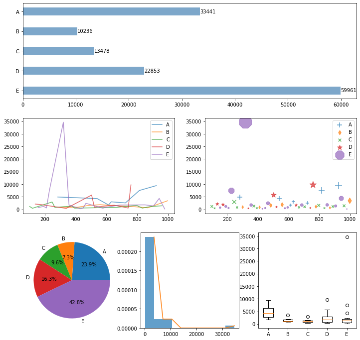

```python
df = pd.DataFrame()
df['City'] = np.linspace(101,999,50).astype(np.int32)
df['GDP'] = np.random.lognormal(np.e**2, 1, 50).astype(np.int64)
df['Letter'] = np.random.choice(np.array(['A', 'B', 'C', 'D', 'E']), size=50, replace=True)

plt.figure(figsize=(12,12))

plt.subplot(3,1,1)
agg_GDP = []
for e in ['A', 'B', 'C', 'D', 'E']:
    agg_GDP.append(df[(df.Letter==e)]['GDP'].sum())
b1 = plt.barh(['A', 'B', 'C', 'D', 'E'][::-1], agg_GDP[::-1], label='GDP', height=0.4, align='center', color='steelblue', alpha = 0.7)
plt.bar_label(b1)

plt.subplot(3,2,3)
df_A = df[(df.Letter=='A')]
df_B = df[(df.Letter=='B')]
df_C = df[(df.Letter=='C')]
df_D = df[(df.Letter=='D')]
df_E = df[(df.Letter=='E')]
plt.plot(df_A['City'], df_A['GDP'], alpha=0.7)
plt.plot(df_B['City'], df_B['GDP'], alpha=0.7)
plt.plot(df_C['City'], df_C['GDP'], alpha=0.7)
plt.plot(df_D['City'], df_D['GDP'], alpha=0.7)
plt.plot(df_E['City'], df_E['GDP'], alpha=0.7)
plt.legend(labels=['A', 'B', 'C', 'D', 'E'], loc='best')

plt.subplot(3,2,4)
plt.scatter(df_A['City'], df_A['GDP'], s=0.02*(np.array(df_A['GDP'])), marker='+',alpha=0.7)
plt.scatter(df_B['City'], df_B['GDP'], s=0.02*(np.array(df_B['GDP'])), marker='d',alpha=0.7)
plt.scatter(df_C['City'], df_C['GDP'], s=0.02*(np.array(df_C['GDP'])), marker='x',alpha=0.7)
plt.scatter(df_D['City'], df_D['GDP'], s=0.02*(np.array(df_D['GDP'])), marker='*',alpha=0.7)
plt.scatter(df_E['City'], df_E['GDP'], s=0.02*(np.array(df_E['GDP'])), marker='8',alpha=0.7)
plt.legend(labels=['A', 'B', 'C', 'D', 'E'], loc='best')

plt.subplot(3,3,7)
plt.pie(agg_GDP, autopct='%1.1f%%',labels=['A', 'B', 'C', 'D', 'E'])

plt.subplot(3,3,8)
count, bins, ignored = plt.hist(df['GDP'], density=True, alpha=0.7)
plt.plot(bins[1:], count)

plt.subplot(3,3,9)
plt.boxplot([df_A['GDP'], df_B['GDP'], df_C['GDP'], df_D['GDP'], df_E['GDP']], labels=['A', 'B', 'C', 'D', 'E'])
pass
```